### The Economic and Gender Disparity in College Majors

### Intro

# Backgorund

**Information on the data:**

- This dataset has served as the foundation to the article [The economic guide to picking a college major](https://fivethirtyeight.com/features/the-economic-guide-to-picking-a-college-major/).
- The dataset we are working with aims to provide information about which majors go on to receive the highest salaries post degree.
- Source: [click here](https://github.com/rfordatascience/tidytuesday/tree/master/data/2018/2018-10-16)

**Variables that we focused on:**

- Rank - The major that made the most money ranked from number 1 being the highest earning major by median salary to lowest.
- Median - The median salary that students of said major go on to recieve post-degree.
- Share_Women - The proportion of women in the major.
- Major_category - The broad category of major.

**What are STEM majors?**

- STEM majors are majors from the fields Science, Technology, Engineering, and Math.

# Goals

Discover which Majors lead to the most profitable jobs, and provide an insight into the distribution of gender amongst the different majors.

- We want to test the assumption that STEM majors have a higher median income then non-STEM majors.  
  In order to do so we will perform a t-test.
- We will use a linear model to show the relationship between the share of women in a major to the rank of the major. Our assumption is that women tend to choose majors that go on to earn a lower median salary.

### Importing Data

# Processing the data

- Data loading
- Rearranging data

```r
suppressWarnings(suppressMessages(library(tidyverse)))
suppressWarnings(suppressMessages(library(scales)))

data <- readr ::read_csv('https://raw.githubusercontent.com/rfordatascience/tidytuesday/master/data/2018/2018-10-16/recent-grads.csv')
majors <-data %>%
  arrange(desc(Median)) %>%
  mutate(Major = str_to_title(Major))
```

# Rearranged data

| Rank | Major_code | Major | Total | Men | Women | Major_category | ShareWomen | Sample_size | Employed | Full_time | Part_time | Full_time_year_round | Unemployed | Unemployment_rate | Median | P25th | P75th | College_jobs | Non_college_jobs | Low_wage_jobs |
| --- | --- | --- | --- | --- | --- | --- | --- | --- | --- | --- | --- | --- | --- | --- | --- | --- | --- | --- | --- | --- |
| 1 | 2419 | Petroleum Engineering | 2339 | 2057 | 282 | Engineering | 0.12056434 | 36 | 1976 | 1849 | 270 | 1207 | 37 | 0.018380527 | 110000 | 95000 | 125000 | 1534 | 364 | 193 |
| 2 | 2416 | Mining And Mineral Engineering | 756 | 679 | 77 | Engineering | 0.10185185 | 7 | 640 | 556 | 170 | 388 | 85 | 0.117241379 | 75000 | 55000 | 90000 | 350 | 257 | 50 |
| 3 | 2415 | Metallurgical Engineering | 856 | 725 | 131 | Engineering | 0.15303738 | 3 | 648 | 558 | 133 | 340 | 16 | 0.024096386 | 73000 | 50000 | 105000 | 456 | 176 | 0 |
| 4 | 2417 | Naval Architecture And Marine Engineering | 1258 | 1123 | 135 | Engineering | 0.10731320 | 16 | 758 | 1069 | 150 | 692 | 40 | 0.050125313 | 70000 | 43000 | 80000 | 529 | 102 | 0 |
| 5 | 2405 | Chemical Engineering | 32260 | 21239 | 11021 | Engineering | 0.34163050 | 289 | 25694 | 23170 | 5180 | 16697 | 1672 | 0.061097712 | 65000 | 50000 | 75000 | 18314 | 4440 | 972 |
| 6 | 2418 | Nuclear Engineering | 2573 | 2200 | 373 | Engineering | 0.14496697 | 17 | 1857 | 2038 | 264 | 1449 | 400 | 0.177226407 | 65000 | 50000 | 102000 | 1142 | 657 | 244 |
| 7 | 6202 | Actuarial Science | 3777 | 2110 | 1667 | Business | 0.44135557 | 51 | 2912 | 2924 | 296 | 2482 | 308 | 0.095652174 | 62000 | 53000 | 72000 | 1768 | 314 | 259 |
| 8 | 5001 | Astronomy And Astrophysics | 1792 | 832 | 960 | Physical Sciences | 0.53571429 | 10 | 1526 | 1085 | 553 | 827 | 33 | 0.021167415 | 62000 | 31500 | 109000 | 972 | 500 | 220 |
| 9 | 2414 | Mechanical Engineering | 91227 | 80320 | 10907 | Engineering | 0.11955890 | 1029 | 76442 | 71298 | 13101 | 54639 | 4650 | 0.057342278 | 60000 | 48000 | 70000 | 52844 | 16384 | 3253 |
| 10 | 2408 | Electrical Engineering | 81527 | 65511 | 16016 | Engineering | 0.19645026 | 631 | 61928 | 55450 | 12695 | 41413 | 3895 | 0.059173845 | 60000 | 45000 | 72000 | 45829 | 10874 | 3170 |

[output cut: 163 more lines]

### Data visualization

# Plotting the data

#### Which categories of major earn the highest median salary?

Lets visualize this with boxplots.

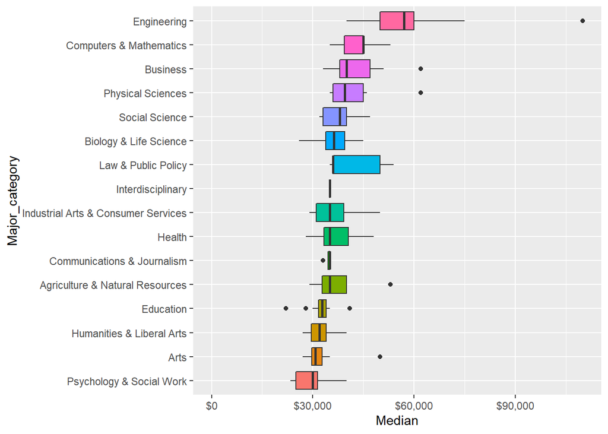

```r
majors %>%
  mutate(Major_category = fct_reorder(Major_category, Median)) %>%
  ggplot(aes(Major_category, Median, fill = Major_category)) +
  geom_boxplot() +
  scale_y_continuous(labels = dollar_format()) +
  expand_limits(y = 0) +
  coord_flip() +
  theme(legend.position = "none")
```

# Outliers

We observe from the boxplot above that there is one major in our sample that earns a much higher median salary(over 100,000$) than the rest of the majors, so we’ll remove it to get a more accurate answer to our hypothesis

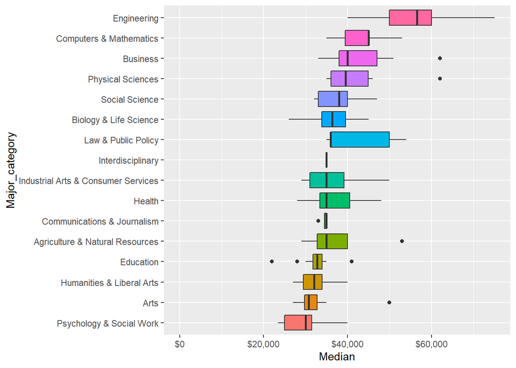

```r
majors_new<-majors[which(majors$Median<100000),]
majors_new %>%
  mutate(Major_category = fct_reorder(Major_category, Median)) %>%
  ggplot(aes(Major_category, Median, fill = Major_category)) +
  geom_boxplot() +
  scale_y_continuous(labels = dollar_format()) +
  expand_limits(y = 0) +
  coord_flip() +
  theme(legend.position = "none")
```

# How does the gender distribution mainfest itself in the choice of major?

As there are many (over 150) different majors let’s have a look at the top 25 largest sampled majors.

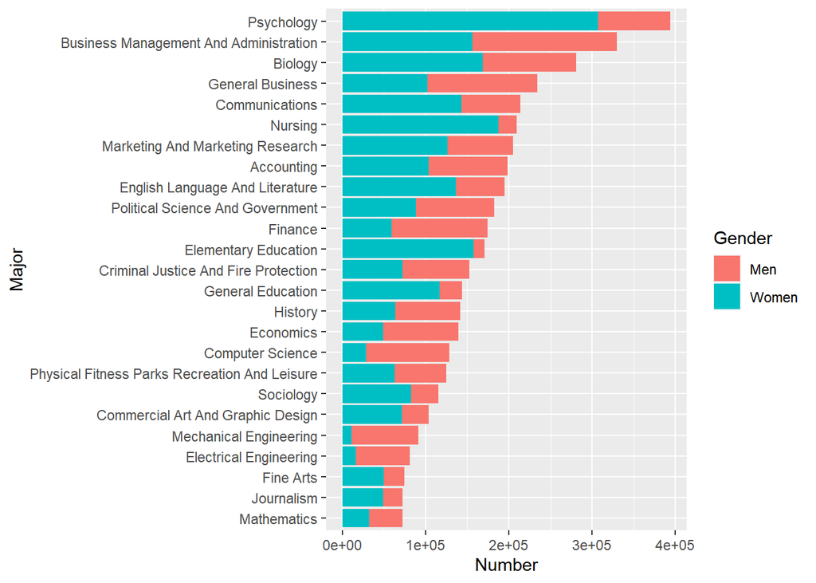

```r
majors %>%
  arrange(desc(Total)) %>%head(25)%>%
  mutate(Major = fct_reorder(Major, Total)) %>%
  gather(Gender, Number, Men, Women) %>%
  ggplot(aes(Major, Number, fill = Gender)) +
  geom_col() +
  coord_flip()
```

### T test

# Do STEM majors earn a higher median salary then non-STEM majors?

**details:**

- Null hypothesis: There is no difference between the mean median salary of STEM majors and non-STEM majors.
- Alternative hypothesis: The mean median salary of STEM majors is greater the non-STEM majors.
- We will test our assumption with a 99% confidence level.
- Reject Null if p value is less than 1%.

**Assumptions:**

- Since our data is large enough we dont need to assume normality.
- The variances are unknown therefor we will use t-test.

$$H_0 : \mu_{stem} - \mu_{non-stem} = 0$$
$$H_1:\mu_{stem} - \mu_{non-stem} > 0$$

```r
stm <- majors_new%>%filter(Major_category == "Engineering" | Major_category == "Physical Sciences" | Major_category == "Computers & Mathematics")

all <- majors_new%>%filter(Major_category != "Engineering" & Major_category != "Physical Sciences" & Major_category != "Computers & Mathematics")

median_sal_all <- pull(all,"Median")
median_sal_stm <-pull(stm,"Median")

t.test(median_sal_stm,median_sal_all,var.equal = F,conf.level = 0.99,mu = 0 ,paired = F,alternative = "greater")
```

```
##
##  Welch Two Sample t-test
##
## data:  median_sal_stm and median_sal_all
## t = 8.7561, df = 64.013, p-value = 7.539e-13
## alternative hypothesis: true difference in means is greater than 0
## 99 percent confidence interval:
##  10291.07      Inf
## sample estimates:
## mean of x mean of y
##  49861.22  35715.45
```

Since our p value is smaller then 1% we reject the null hypothesis.

### Regression

#### Gender as an Indicator of Wages

We want to build a model that expresses the relationship between the share of women in a major and the rank of the major.

```r
women_lm <- lm(formula = majors$ShareWomen ~ majors$Rank, data = majors)
summary(women_lm)
```

```
##
## Call:
## lm(formula = majors$ShareWomen ~ majors$Rank, data = majors)
##
## Residuals:
##      Min       1Q   Median       3Q      Max
## -0.48239 -0.11142  0.00333  0.12164  0.52977
##
## Coefficients:
##              Estimate Std. Error t value Pr(>|t|)
## (Intercept) 0.2620197  0.0273081   9.595   <2e-16 ***
## majors$Rank 0.0029779  0.0002715  10.969   <2e-16 ***
## ---
## Signif. codes:  0 '***' 0.001 '**' 0.01 '*' 0.05 '.' 0.1 ' ' 1
##
## Residual standard error: 0.1774 on 170 degrees of freedom
##   (1 observation deleted due to missingness)
## Multiple R-squared:  0.4145, Adjusted R-squared:  0.411
## F-statistic: 120.3 on 1 and 170 DF,  p-value: < 2.2e-16
```

Based on the regression model output, we observe that the Rank of the major is a significant predictor of the share of women in said Major.  
We can see from our modle output that the R-squared is around 0.41 which show us the 40% of the variation in share of women can explained by rank of major. We can also see that rank is siginficant coefficient for determining the share of women based on the extremely low p value.

#### We’ll express this relationship visually:

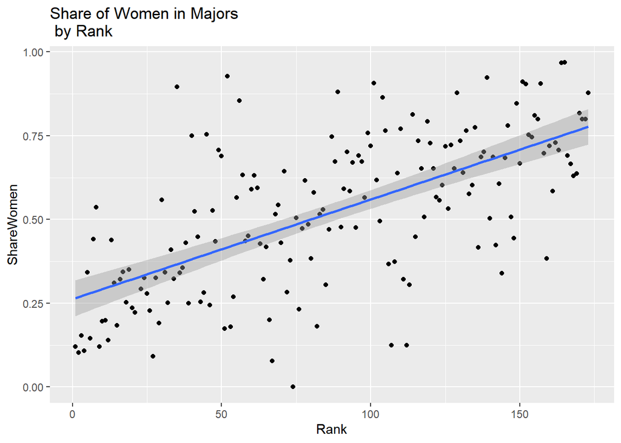

```r
ggplot(data,aes(x=majors$Rank,y = majors$ShareWomen))+
  geom_point()+geom_smooth(method = "lm")+
  labs(title="Share of Women in Majors \n by Rank", x ="Rank", y = "ShareWomen")
```

#### We can visualize this in a different way using the median salary as opposed to the rank:

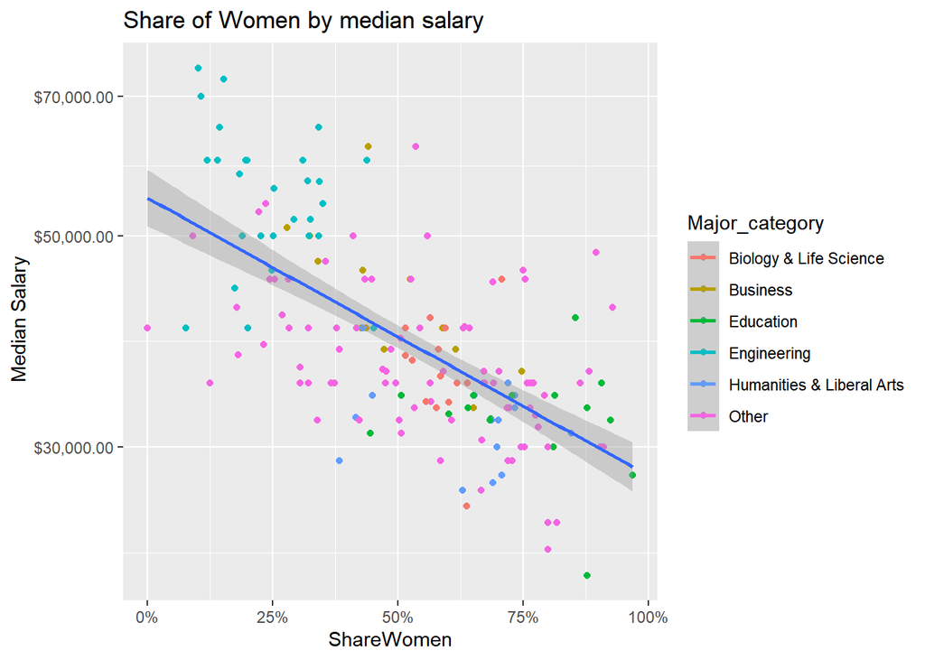

```r
women_salary<- majors_new %>%
  mutate(Major_category = fct_lump(Major_category, 5))
  ggplot(data = women_salary,aes(ShareWomen, Median, color = Major_category, label = Major)) +
  geom_point() +
  geom_smooth(aes(group = 1), method = "lm") +
  scale_x_continuous(labels = percent_format()) +
  scale_y_log10(labels = dollar_format())+labs(title = "Share of Women by median salary",x ="ShareWomen",y =" Median Salary")
```

```r
women_lm <-lm(Median~ShareWomen,data = majors_new)
summary(women_lm)
```

```
##
## Call:
## lm(formula = Median ~ ShareWomen, data = majors_new)
##
## Residuals:
##    Min     1Q Median     3Q    Max
## -15888  -5198  -1213   3508  23463
##
## Coefficients:
##             Estimate Std. Error t value Pr(>|t|)
## (Intercept)    54397       1503   36.18   <2e-16 ***
## ShareWomen    -28078       2626  -10.69   <2e-16 ***
## ---
## Signif. codes:  0 '***' 0.001 '**' 0.01 '*' 0.05 '.' 0.1 ' ' 1
##
## Residual standard error: 7870 on 169 degrees of freedom
##   (1 observation deleted due to missingness)
## Multiple R-squared:  0.4034, Adjusted R-squared:  0.3999
## F-statistic: 114.3 on 1 and 169 DF,  p-value: < 2.2e-16
```

We can see from this plot that the majors that have the highest median salary(Engineering) tend to have the lowest share of women in them and the majors that recieve the lowest salary tend to have the highest share of women. This goes to show that women tend to choose majors with lower median salary then men.

### About

This study was made as a final project in the course “Introduction to statistic and data analysis in R”

**Authors:**

- Ezra Tawil
- Issachar Penya

# Techinical:

The data analysis and this markdown page were made with R version 4.0.2 in RStudio.

**libraries:**

- [tidyverse](https://www.tidyverse.org/packages/)
- [scales](https://www.rdocumentation.org/packages/scales/versions/0.4.1)
- klippy

Back to top